# energyAnalysis

```python
import numpy as np
import pandas as pd
import scipy.stats as st
import scipy.special
from dateutil.parser import parse
import statsmodels.tools.numdiff as smnd

import matplotlib.pyplot as plt
%matplotlib inline
import sys
sys.path.insert(1, r'./../functions')  # add to pythonpath
from detect_peaks import detect_peaks

import bokeh.io
import bokeh.plotting

import holoviews as hv

hv.extension('bokeh')
bokeh.io.output_notebook()
```

## section 1

Load in our dataset

```python
df = pd.read_csv("data/data.csv")
df
```

|  | Month | United States : all fuels (utility-scale) thousand megawatthours | United States : coal thousand megawatthours | United States : natural gas thousand megawatthours | United States : nuclear thousand megawatthours | United States : conventional hydroelectric thousand megawatthours | United States : wind thousand megawatthours | United States : all solar thousand megawatthours |
| --- | --- | --- | --- | --- | --- | --- | --- | --- |
| 0 | Sep-17 | 334151.8952 | 98415.98694 | 116670.78730 | 68073.359 | 18962.77972 | 17291.38606 | 7383.71271 |
| 1 | Aug-17 | 382254.6077 | 119879.96220 | 139603.45100 | 72384.218 | 21238.69313 | 13146.87384 | 7879.48046 |
| 2 | Jul-17 | 401571.5968 | 127984.19910 | 144715.56990 | 71314.219 | 25740.97144 | 15846.18551 | 8060.53166 |
| 3 | Jun-17 | 357285.7003 | 107728.58930 | 116062.36190 | 67010.782 | 30423.07689 | 19642.38432 | 8733.13596 |
| 4 | May-17 | 321158.9279 | 92464.49419 | 96782.32036 | 61309.446 | 32181.39540 | 22605.81482 | 8187.94816 |
| 5 | Apr-17 | 293839.8880 | 81532.41030 | 86325.52923 | 56743.352 | 29322.14615 | 25722.10026 | 6970.16868 |
| 6 | Mar-17 | 320413.3081 | 89425.95718 | 94956.21908 | 65093.200 | 30221.18164 | 26029.84942 | 6407.58943 |
| 7 | Feb-17 | 290166.2507 | 86872.76655 | 80510.17332 | 64052.805 | 24543.09149 | 22088.20390 | 3887.1662 |
| 8 | Jan-17 | 341388.8570 | 115501.12420 | 91409.82503 | 73120.612 | 27857.66552 | 20607.40210 | 3376.91369 |
| 9 | Dec-16 | 345355.0046 | 118746.84190 | 96363.59628 | 71662.429 | 22527.76456 | 23145.52474 | 3590.66861 |
| 10 | Nov-16 | 297075.4081 | 86940.46241 | 93941.83450 | 65178.776 | 18808.26528 | 19405.64211 | 4023.9887 |
| 11 | Oct-16 | 312958.1360 | 99193.94367 | 102897.98610 | 60733.343 | 17338.85654 | 20335.38978 | 4743.28769 |
| 12 | Sep-16 | 351497.8117 | 114137.76830 | 125602.73980 | 65448.176 | 16367.68403 | 16403.64017 | 5370.44767 |
| 13 | Aug-16 | 409715.4707 | 135634.73330 | 154759.67320 | 71526.405 | 19569.54914 | 13589.32615 | 5910.82805 |
| 14 | Jul-16 | 411901.1987 | 136316.43400 | 151553.87200 | 70349.347 | 21455.32093 | 17618.35712 | 5945.07716 |
| 15 | Jun-16 | 367795.5466 | 116034.38410 | 131395.22910 | 67175.324 | 23236.86739 | 16303.44130 | 5401.26493 |
| 16 | May-16 | 316799.7095 | 81694.51025 | 110430.19230 | 66576.493 | 25486.38143 | 18847.89867 | 5304.17484 |
| 17 | Apr-16 | 292907.9820 | 72112.86190 | 98875.94730 | 62731.845 | 25878.02878 | 20799.30345 | 4582.61853 |
| 18 | Mar-16 | 304403.4231 | 72172.52681 | 103889.93760 | 66148.894 | 27389.87720 | 21939.40933 | 4142.59215 |
| 19 | Feb-16 | 313698.7306 | 92704.80797 | 98552.17908 | 65638.141 | 24139.01548 | 20138.22780 | 3386.13613 |
| 20 | Jan-16 | 352719.0660 | 113459.37980 | 110043.74670 | 72524.775 | 25614.54233 | 18466.40151 | 2465.40732 |
| 21 | Dec-15 | 324427.2235 | 89495.07284 | 109776.67890 | 69633.664 | 23165.56195 | 20098.37277 | 2483.85893 |
| 22 | Nov-15 | 300653.2675 | 87227.13603 | 102236.25480 | 60263.941 | 19337.83088 | 19681.71564 | 2711.70957 |
| 23 | Oct-15 | 312111.6799 | 96758.50415 | 110005.03900 | 60570.921 | 16630.40155 | 16380.03853 | 3107.28733 |
| 24 | Sep-15 | 350121.6482 | 117985.63220 | 123035.92240 | 66476.372 | 16094.12240 | 13971.56651 | 3546.77556 |
| 25 | Aug-15 | 392116.2030 | 134670.30890 | 139083.75440 | 72415.352 | 19122.10511 | 13080.02756 | 4155.60157 |
| 26 | Jul-15 | 400418.8528 | 139099.86860 | 141119.08130 | 71412.176 | 21014.22144 | 13675.44937 | 4113.74514 |
| 27 | Jun-15 | 362409.2018 | 125673.11370 | 121477.74920 | 68516.165 | 20414.08400 | 13421.26619 | 3965.61172 |
| 28 | May-15 | 322086.9121 | 104584.52670 | 101516.35450 | 65826.525 | 20125.41560 | 17151.34131 | 3897.98556 |
| 29 | Apr-15 | 294133.3424 | 88989.14250 | 92805.99824 | 59784.495 | 22470.97723 | 17867.14921 | 3642.64641 |
| ... | ... | ... | ... | ... | ... | ... | ... | ... |
| 171 | Jun-03 | 328693.6980 | 162284.63000 | 54452.95100 | 64180.727 | 28586.30000 | 1047.14400 | NaN |
| 172 | May-03 | 307544.8870 | 150262.97700 | 49372.96300 | 62201.960 | 29395.25600 | 1006.38300 | NaN |
| 173 | Apr-03 | 285755.6990 | 141959.98100 | 45195.38300 | 56775.591 | 24758.96200 | 1092.76600 | NaN |
| 174 | Mar-03 | 304317.2650 | 155001.77500 | 46699.02600 | 59933.261 | 24202.27300 | 1036.10400 | NaN |
| 175 | Feb-03 | 299248.7770 | 156982.48100 | 43546.57300 | 60941.869 | 19779.86000 | 745.37500 | NaN |
| 176 | Jan-03 | 341988.9010 | 181313.15300 | 50175.74600 | 69211.084 | 20600.07900 | 632.34000 | NaN |
| 177 | Dec-02 | 324833.7050 | 172189.76500 | 46100.39300 | 68905.472 | 21668.54000 | 755.19400 | NaN |
| 178 | Nov-02 | 296289.5610 | 156053.65500 | 45160.87600 | 61520.324 | 19730.02900 | 655.94600 | NaN |
| 179 | Oct-02 | 307059.4600 | 159099.29400 | 54200.82000 | 60493.052 | 17171.33400 | 734.35500 | NaN |
| 180 | Sep-02 | 331279.4340 | 165366.30900 | 68161.13100 | 64480.790 | 17086.78200 | 735.82800 | NaN |
| 181 | Aug-02 | 374585.8190 | 179955.44700 | 84476.86700 | 70777.688 | 21083.92400 | 976.69100 | NaN |
| 182 | Jul-02 | 381542.1070 | 183194.70200 | 83917.26900 | 70420.827 | 25470.64700 | 890.45500 | NaN |
| 183 | Jun-02 | 341023.1440 | 164667.69500 | 65631.01800 | 66371.896 | 28212.84700 | 1126.31500 | NaN |
| 184 | May-02 | 307674.5690 | 151406.40100 | 50275.23700 | 63032.192 | 26662.69500 | 1077.64100 | NaN |
| 185 | Apr-02 | 289848.2530 | 142304.59500 | 49146.40900 | 58437.062 | 24246.60500 | 1024.41700 | NaN |
| 186 | Mar-02 | 302549.0110 | 151485.65100 | 51214.46400 | 63040.647 | 21008.81300 | 852.10200 | NaN |
| 187 | Feb-02 | 281825.7120 | 143048.82200 | 44308.43100 | 61658.274 | 20191.68300 | 713.93200 | NaN |
| 188 | Jan-02 | 319941.4760 | 164358.01800 | 48412.83200 | 70925.863 | 21794.93200 | 811.40200 | NaN |
| 189 | Dec-01 | 305496.3280 | 157402.35000 | 47540.86100 | 67430.878 | 19346.31400 | 615.65700 | NaN |
| 190 | Nov-01 | 278933.9420 | 144116.99800 | 44490.62200 | 62341.711 | 15412.92900 | 470.44800 | NaN |
| 191 | Oct-01 | 294733.6130 | 148930.81600 | 56376.44100 | 60460.967 | 15234.50300 | 606.82900 | NaN |
| 192 | Sep-01 | 306928.8660 | 154158.31700 | 60181.14000 | 63378.451 | 15256.02700 | 490.22900 | NaN |
| 193 | Aug-01 | 370532.8280 | 183116.07300 | 78409.80400 | 68389.496 | 18913.76800 | 577.20600 | NaN |
| 194 | Jul-01 | 357613.7000 | 179060.41000 | 73030.14200 | 69166.040 | 18079.11900 | 634.99200 | NaN |
| 195 | Jun-01 | 327693.9780 | 162615.80400 | 57603.15400 | 68023.098 | 20727.63000 | 669.63400 | NaN |
| 196 | May-01 | 300491.6210 | 151592.91400 | 50934.20500 | 61512.445 | 19175.63500 | 635.02900 | NaN |
| 197 | Apr-01 | 278078.8710 | 140670.65400 | 45842.74600 | 56003.026 | 18012.99400 | 684.69500 | NaN |
| 198 | Mar-01 | 300706.5440 | 155269.01100 | 44364.41400 | 62140.712 | 20477.18900 | 532.12000 | NaN |
| 199 | Feb-01 | 282940.1980 | 149735.48400 | 37966.92700 | 61272.407 | 17472.88900 | 431.24200 | NaN |
| 200 | Jan-01 | 332493.1600 | 177287.11100 | 42388.66300 | 68707.077 | 18852.04800 | 389.25000 |  |

201 rows × 8 columns

Reverse all the columns in order to start from Jan-01

```python
df['Month'][0]

df = df.sort_index(axis=1 ,ascending=True)
df = df.iloc[::-1]
df = df.sort_index(ascending=True, axis=0)
df = df.reindex(index=df.index[::-1])
df
```

|  | Month | United States : all fuels (utility-scale) thousand megawatthours | United States : all solar thousand megawatthours | United States : coal thousand megawatthours | United States : conventional hydroelectric thousand megawatthours | United States : natural gas thousand megawatthours | United States : nuclear thousand megawatthours | United States : wind thousand megawatthours |
| --- | --- | --- | --- | --- | --- | --- | --- | --- |
| 200 | Jan-01 | 332493.1600 |  | 177287.11100 | 18852.04800 | 42388.66300 | 68707.077 | 389.25000 |
| 199 | Feb-01 | 282940.1980 | NaN | 149735.48400 | 17472.88900 | 37966.92700 | 61272.407 | 431.24200 |
| 198 | Mar-01 | 300706.5440 | NaN | 155269.01100 | 20477.18900 | 44364.41400 | 62140.712 | 532.12000 |
| 197 | Apr-01 | 278078.8710 | NaN | 140670.65400 | 18012.99400 | 45842.74600 | 56003.026 | 684.69500 |
| 196 | May-01 | 300491.6210 | NaN | 151592.91400 | 19175.63500 | 50934.20500 | 61512.445 | 635.02900 |
| 195 | Jun-01 | 327693.9780 | NaN | 162615.80400 | 20727.63000 | 57603.15400 | 68023.098 | 669.63400 |
| 194 | Jul-01 | 357613.7000 | NaN | 179060.41000 | 18079.11900 | 73030.14200 | 69166.040 | 634.99200 |
| 193 | Aug-01 | 370532.8280 | NaN | 183116.07300 | 18913.76800 | 78409.80400 | 68389.496 | 577.20600 |
| 192 | Sep-01 | 306928.8660 | NaN | 154158.31700 | 15256.02700 | 60181.14000 | 63378.451 | 490.22900 |
| 191 | Oct-01 | 294733.6130 | NaN | 148930.81600 | 15234.50300 | 56376.44100 | 60460.967 | 606.82900 |
| 190 | Nov-01 | 278933.9420 | NaN | 144116.99800 | 15412.92900 | 44490.62200 | 62341.711 | 470.44800 |
| 189 | Dec-01 | 305496.3280 | NaN | 157402.35000 | 19346.31400 | 47540.86100 | 67430.878 | 615.65700 |
| 188 | Jan-02 | 319941.4760 | NaN | 164358.01800 | 21794.93200 | 48412.83200 | 70925.863 | 811.40200 |
| 187 | Feb-02 | 281825.7120 | NaN | 143048.82200 | 20191.68300 | 44308.43100 | 61658.274 | 713.93200 |
| 186 | Mar-02 | 302549.0110 | NaN | 151485.65100 | 21008.81300 | 51214.46400 | 63040.647 | 852.10200 |
| 185 | Apr-02 | 289848.2530 | NaN | 142304.59500 | 24246.60500 | 49146.40900 | 58437.062 | 1024.41700 |
| 184 | May-02 | 307674.5690 | NaN | 151406.40100 | 26662.69500 | 50275.23700 | 63032.192 | 1077.64100 |
| 183 | Jun-02 | 341023.1440 | NaN | 164667.69500 | 28212.84700 | 65631.01800 | 66371.896 | 1126.31500 |
| 182 | Jul-02 | 381542.1070 | NaN | 183194.70200 | 25470.64700 | 83917.26900 | 70420.827 | 890.45500 |
| 181 | Aug-02 | 374585.8190 | NaN | 179955.44700 | 21083.92400 | 84476.86700 | 70777.688 | 976.69100 |
| 180 | Sep-02 | 331279.4340 | NaN | 165366.30900 | 17086.78200 | 68161.13100 | 64480.790 | 735.82800 |
| 179 | Oct-02 | 307059.4600 | NaN | 159099.29400 | 17171.33400 | 54200.82000 | 60493.052 | 734.35500 |
| 178 | Nov-02 | 296289.5610 | NaN | 156053.65500 | 19730.02900 | 45160.87600 | 61520.324 | 655.94600 |
| 177 | Dec-02 | 324833.7050 | NaN | 172189.76500 | 21668.54000 | 46100.39300 | 68905.472 | 755.19400 |
| 176 | Jan-03 | 341988.9010 | NaN | 181313.15300 | 20600.07900 | 50175.74600 | 69211.084 | 632.34000 |
| 175 | Feb-03 | 299248.7770 | NaN | 156982.48100 | 19779.86000 | 43546.57300 | 60941.869 | 745.37500 |
| 174 | Mar-03 | 304317.2650 | NaN | 155001.77500 | 24202.27300 | 46699.02600 | 59933.261 | 1036.10400 |
| 173 | Apr-03 | 285755.6990 | NaN | 141959.98100 | 24758.96200 | 45195.38300 | 56775.591 | 1092.76600 |
| 172 | May-03 | 307544.8870 | NaN | 150262.97700 | 29395.25600 | 49372.96300 | 62201.960 | 1006.38300 |
| 171 | Jun-03 | 328693.6980 | NaN | 162284.63000 | 28586.30000 | 54452.95100 | 64180.727 | 1047.14400 |
| ... | ... | ... | ... | ... | ... | ... | ... | ... |
| 29 | Apr-15 | 294133.3424 | 3642.64641 | 88989.14250 | 22470.97723 | 92805.99824 | 59784.495 | 17867.14921 |
| 28 | May-15 | 322086.9121 | 3897.98556 | 104584.52670 | 20125.41560 | 101516.35450 | 65826.525 | 17151.34131 |
| 27 | Jun-15 | 362409.2018 | 3965.61172 | 125673.11370 | 20414.08400 | 121477.74920 | 68516.165 | 13421.26619 |
| 26 | Jul-15 | 400418.8528 | 4113.74514 | 139099.86860 | 21014.22144 | 141119.08130 | 71412.176 | 13675.44937 |
| 25 | Aug-15 | 392116.2030 | 4155.60157 | 134670.30890 | 19122.10511 | 139083.75440 | 72415.352 | 13080.02756 |
| 24 | Sep-15 | 350121.6482 | 3546.77556 | 117985.63220 | 16094.12240 | 123035.92240 | 66476.372 | 13971.56651 |
| 23 | Oct-15 | 312111.6799 | 3107.28733 | 96758.50415 | 16630.40155 | 110005.03900 | 60570.921 | 16380.03853 |
| 22 | Nov-15 | 300653.2675 | 2711.70957 | 87227.13603 | 19337.83088 | 102236.25480 | 60263.941 | 19681.71564 |
| 21 | Dec-15 | 324427.2235 | 2483.85893 | 89495.07284 | 23165.56195 | 109776.67890 | 69633.664 | 20098.37277 |
| 20 | Jan-16 | 352719.0660 | 2465.40732 | 113459.37980 | 25614.54233 | 110043.74670 | 72524.775 | 18466.40151 |
| 19 | Feb-16 | 313698.7306 | 3386.13613 | 92704.80797 | 24139.01548 | 98552.17908 | 65638.141 | 20138.22780 |
| 18 | Mar-16 | 304403.4231 | 4142.59215 | 72172.52681 | 27389.87720 | 103889.93760 | 66148.894 | 21939.40933 |
| 17 | Apr-16 | 292907.9820 | 4582.61853 | 72112.86190 | 25878.02878 | 98875.94730 | 62731.845 | 20799.30345 |
| 16 | May-16 | 316799.7095 | 5304.17484 | 81694.51025 | 25486.38143 | 110430.19230 | 66576.493 | 18847.89867 |
| 15 | Jun-16 | 367795.5466 | 5401.26493 | 116034.38410 | 23236.86739 | 131395.22910 | 67175.324 | 16303.44130 |
| 14 | Jul-16 | 411901.1987 | 5945.07716 | 136316.43400 | 21455.32093 | 151553.87200 | 70349.347 | 17618.35712 |
| 13 | Aug-16 | 409715.4707 | 5910.82805 | 135634.73330 | 19569.54914 | 154759.67320 | 71526.405 | 13589.32615 |
| 12 | Sep-16 | 351497.8117 | 5370.44767 | 114137.76830 | 16367.68403 | 125602.73980 | 65448.176 | 16403.64017 |
| 11 | Oct-16 | 312958.1360 | 4743.28769 | 99193.94367 | 17338.85654 | 102897.98610 | 60733.343 | 20335.38978 |
| 10 | Nov-16 | 297075.4081 | 4023.9887 | 86940.46241 | 18808.26528 | 93941.83450 | 65178.776 | 19405.64211 |
| 9 | Dec-16 | 345355.0046 | 3590.66861 | 118746.84190 | 22527.76456 | 96363.59628 | 71662.429 | 23145.52474 |
| 8 | Jan-17 | 341388.8570 | 3376.91369 | 115501.12420 | 27857.66552 | 91409.82503 | 73120.612 | 20607.40210 |
| 7 | Feb-17 | 290166.2507 | 3887.1662 | 86872.76655 | 24543.09149 | 80510.17332 | 64052.805 | 22088.20390 |
| 6 | Mar-17 | 320413.3081 | 6407.58943 | 89425.95718 | 30221.18164 | 94956.21908 | 65093.200 | 26029.84942 |
| 5 | Apr-17 | 293839.8880 | 6970.16868 | 81532.41030 | 29322.14615 | 86325.52923 | 56743.352 | 25722.10026 |
| 4 | May-17 | 321158.9279 | 8187.94816 | 92464.49419 | 32181.39540 | 96782.32036 | 61309.446 | 22605.81482 |
| 3 | Jun-17 | 357285.7003 | 8733.13596 | 107728.58930 | 30423.07689 | 116062.36190 | 67010.782 | 19642.38432 |
| 2 | Jul-17 | 401571.5968 | 8060.53166 | 127984.19910 | 25740.97144 | 144715.56990 | 71314.219 | 15846.18551 |
| 1 | Aug-17 | 382254.6077 | 7879.48046 | 119879.96220 | 21238.69313 | 139603.45100 | 72384.218 | 13146.87384 |
| 0 | Sep-17 | 334151.8952 | 7383.71271 | 98415.98694 | 18962.77972 | 116670.78730 | 68073.359 | 17291.38606 |

201 rows × 8 columns

Remove all NaNs and string elements. Only need to do this on the solar column

```python
for x in range(len(df["United States : all solar thousand megawatthours"])):
    if df["United States : all solar thousand megawatthours"].iloc[x] == ' ' or \
        (type(df["United States : all solar thousand megawatthours"].iloc[x]) == float and \
         np.isnan(df["United States : all solar thousand megawatthours"].iloc[x])):
        df["United States : all solar thousand megawatthours"].iloc[x] = 0.0

df["United States : all solar thousand megawatthours"] = \
    pd.to_numeric(df["United States : all solar thousand megawatthours"])
df
```

|  | Month | United States : all fuels (utility-scale) thousand megawatthours | United States : all solar thousand megawatthours | United States : coal thousand megawatthours | United States : conventional hydroelectric thousand megawatthours | United States : natural gas thousand megawatthours | United States : nuclear thousand megawatthours | United States : wind thousand megawatthours |
| --- | --- | --- | --- | --- | --- | --- | --- | --- |
| 200 | Jan-01 | 332493.1600 | 0.00000 | 177287.11100 | 18852.04800 | 42388.66300 | 68707.077 | 389.25000 |
| 199 | Feb-01 | 282940.1980 | 0.00000 | 149735.48400 | 17472.88900 | 37966.92700 | 61272.407 | 431.24200 |
| 198 | Mar-01 | 300706.5440 | 0.00000 | 155269.01100 | 20477.18900 | 44364.41400 | 62140.712 | 532.12000 |
| 197 | Apr-01 | 278078.8710 | 0.00000 | 140670.65400 | 18012.99400 | 45842.74600 | 56003.026 | 684.69500 |
| 196 | May-01 | 300491.6210 | 0.00000 | 151592.91400 | 19175.63500 | 50934.20500 | 61512.445 | 635.02900 |
| 195 | Jun-01 | 327693.9780 | 0.00000 | 162615.80400 | 20727.63000 | 57603.15400 | 68023.098 | 669.63400 |
| 194 | Jul-01 | 357613.7000 | 0.00000 | 179060.41000 | 18079.11900 | 73030.14200 | 69166.040 | 634.99200 |
| 193 | Aug-01 | 370532.8280 | 0.00000 | 183116.07300 | 18913.76800 | 78409.80400 | 68389.496 | 577.20600 |
| 192 | Sep-01 | 306928.8660 | 0.00000 | 154158.31700 | 15256.02700 | 60181.14000 | 63378.451 | 490.22900 |
| 191 | Oct-01 | 294733.6130 | 0.00000 | 148930.81600 | 15234.50300 | 56376.44100 | 60460.967 | 606.82900 |
| 190 | Nov-01 | 278933.9420 | 0.00000 | 144116.99800 | 15412.92900 | 44490.62200 | 62341.711 | 470.44800 |
| 189 | Dec-01 | 305496.3280 | 0.00000 | 157402.35000 | 19346.31400 | 47540.86100 | 67430.878 | 615.65700 |
| 188 | Jan-02 | 319941.4760 | 0.00000 | 164358.01800 | 21794.93200 | 48412.83200 | 70925.863 | 811.40200 |
| 187 | Feb-02 | 281825.7120 | 0.00000 | 143048.82200 | 20191.68300 | 44308.43100 | 61658.274 | 713.93200 |
| 186 | Mar-02 | 302549.0110 | 0.00000 | 151485.65100 | 21008.81300 | 51214.46400 | 63040.647 | 852.10200 |
| 185 | Apr-02 | 289848.2530 | 0.00000 | 142304.59500 | 24246.60500 | 49146.40900 | 58437.062 | 1024.41700 |
| 184 | May-02 | 307674.5690 | 0.00000 | 151406.40100 | 26662.69500 | 50275.23700 | 63032.192 | 1077.64100 |
| 183 | Jun-02 | 341023.1440 | 0.00000 | 164667.69500 | 28212.84700 | 65631.01800 | 66371.896 | 1126.31500 |
| 182 | Jul-02 | 381542.1070 | 0.00000 | 183194.70200 | 25470.64700 | 83917.26900 | 70420.827 | 890.45500 |
| 181 | Aug-02 | 374585.8190 | 0.00000 | 179955.44700 | 21083.92400 | 84476.86700 | 70777.688 | 976.69100 |
| 180 | Sep-02 | 331279.4340 | 0.00000 | 165366.30900 | 17086.78200 | 68161.13100 | 64480.790 | 735.82800 |
| 179 | Oct-02 | 307059.4600 | 0.00000 | 159099.29400 | 17171.33400 | 54200.82000 | 60493.052 | 734.35500 |
| 178 | Nov-02 | 296289.5610 | 0.00000 | 156053.65500 | 19730.02900 | 45160.87600 | 61520.324 | 655.94600 |
| 177 | Dec-02 | 324833.7050 | 0.00000 | 172189.76500 | 21668.54000 | 46100.39300 | 68905.472 | 755.19400 |
| 176 | Jan-03 | 341988.9010 | 0.00000 | 181313.15300 | 20600.07900 | 50175.74600 | 69211.084 | 632.34000 |
| 175 | Feb-03 | 299248.7770 | 0.00000 | 156982.48100 | 19779.86000 | 43546.57300 | 60941.869 | 745.37500 |
| 174 | Mar-03 | 304317.2650 | 0.00000 | 155001.77500 | 24202.27300 | 46699.02600 | 59933.261 | 1036.10400 |
| 173 | Apr-03 | 285755.6990 | 0.00000 | 141959.98100 | 24758.96200 | 45195.38300 | 56775.591 | 1092.76600 |
| 172 | May-03 | 307544.8870 | 0.00000 | 150262.97700 | 29395.25600 | 49372.96300 | 62201.960 | 1006.38300 |
| 171 | Jun-03 | 328693.6980 | 0.00000 | 162284.63000 | 28586.30000 | 54452.95100 | 64180.727 | 1047.14400 |
| ... | ... | ... | ... | ... | ... | ... | ... | ... |
| 29 | Apr-15 | 294133.3424 | 3642.64641 | 88989.14250 | 22470.97723 | 92805.99824 | 59784.495 | 17867.14921 |
| 28 | May-15 | 322086.9121 | 3897.98556 | 104584.52670 | 20125.41560 | 101516.35450 | 65826.525 | 17151.34131 |
| 27 | Jun-15 | 362409.2018 | 3965.61172 | 125673.11370 | 20414.08400 | 121477.74920 | 68516.165 | 13421.26619 |
| 26 | Jul-15 | 400418.8528 | 4113.74514 | 139099.86860 | 21014.22144 | 141119.08130 | 71412.176 | 13675.44937 |
| 25 | Aug-15 | 392116.2030 | 4155.60157 | 134670.30890 | 19122.10511 | 139083.75440 | 72415.352 | 13080.02756 |
| 24 | Sep-15 | 350121.6482 | 3546.77556 | 117985.63220 | 16094.12240 | 123035.92240 | 66476.372 | 13971.56651 |
| 23 | Oct-15 | 312111.6799 | 3107.28733 | 96758.50415 | 16630.40155 | 110005.03900 | 60570.921 | 16380.03853 |
| 22 | Nov-15 | 300653.2675 | 2711.70957 | 87227.13603 | 19337.83088 | 102236.25480 | 60263.941 | 19681.71564 |
| 21 | Dec-15 | 324427.2235 | 2483.85893 | 89495.07284 | 23165.56195 | 109776.67890 | 69633.664 | 20098.37277 |
| 20 | Jan-16 | 352719.0660 | 2465.40732 | 113459.37980 | 25614.54233 | 110043.74670 | 72524.775 | 18466.40151 |
| 19 | Feb-16 | 313698.7306 | 3386.13613 | 92704.80797 | 24139.01548 | 98552.17908 | 65638.141 | 20138.22780 |
| 18 | Mar-16 | 304403.4231 | 4142.59215 | 72172.52681 | 27389.87720 | 103889.93760 | 66148.894 | 21939.40933 |
| 17 | Apr-16 | 292907.9820 | 4582.61853 | 72112.86190 | 25878.02878 | 98875.94730 | 62731.845 | 20799.30345 |
| 16 | May-16 | 316799.7095 | 5304.17484 | 81694.51025 | 25486.38143 | 110430.19230 | 66576.493 | 18847.89867 |
| 15 | Jun-16 | 367795.5466 | 5401.26493 | 116034.38410 | 23236.86739 | 131395.22910 | 67175.324 | 16303.44130 |
| 14 | Jul-16 | 411901.1987 | 5945.07716 | 136316.43400 | 21455.32093 | 151553.87200 | 70349.347 | 17618.35712 |
| 13 | Aug-16 | 409715.4707 | 5910.82805 | 135634.73330 | 19569.54914 | 154759.67320 | 71526.405 | 13589.32615 |
| 12 | Sep-16 | 351497.8117 | 5370.44767 | 114137.76830 | 16367.68403 | 125602.73980 | 65448.176 | 16403.64017 |
| 11 | Oct-16 | 312958.1360 | 4743.28769 | 99193.94367 | 17338.85654 | 102897.98610 | 60733.343 | 20335.38978 |
| 10 | Nov-16 | 297075.4081 | 4023.98870 | 86940.46241 | 18808.26528 | 93941.83450 | 65178.776 | 19405.64211 |
| 9 | Dec-16 | 345355.0046 | 3590.66861 | 118746.84190 | 22527.76456 | 96363.59628 | 71662.429 | 23145.52474 |
| 8 | Jan-17 | 341388.8570 | 3376.91369 | 115501.12420 | 27857.66552 | 91409.82503 | 73120.612 | 20607.40210 |
| 7 | Feb-17 | 290166.2507 | 3887.16620 | 86872.76655 | 24543.09149 | 80510.17332 | 64052.805 | 22088.20390 |
| 6 | Mar-17 | 320413.3081 | 6407.58943 | 89425.95718 | 30221.18164 | 94956.21908 | 65093.200 | 26029.84942 |
| 5 | Apr-17 | 293839.8880 | 6970.16868 | 81532.41030 | 29322.14615 | 86325.52923 | 56743.352 | 25722.10026 |
| 4 | May-17 | 321158.9279 | 8187.94816 | 92464.49419 | 32181.39540 | 96782.32036 | 61309.446 | 22605.81482 |
| 3 | Jun-17 | 357285.7003 | 8733.13596 | 107728.58930 | 30423.07689 | 116062.36190 | 67010.782 | 19642.38432 |
| 2 | Jul-17 | 401571.5968 | 8060.53166 | 127984.19910 | 25740.97144 | 144715.56990 | 71314.219 | 15846.18551 |
| 1 | Aug-17 | 382254.6077 | 7879.48046 | 119879.96220 | 21238.69313 | 139603.45100 | 72384.218 | 13146.87384 |
| 0 | Sep-17 | 334151.8952 | 7383.71271 | 98415.98694 | 18962.77972 | 116670.78730 | 68073.359 | 17291.38606 |

201 rows × 8 columns

Get values of dataframe in an organized manner

```python
allFuels = df["United States : all fuels (utility-scale) thousand megawatthours"].values
solar = df["United States : all solar thousand megawatthours"].values
coal = df["United States : coal thousand megawatthours"].values
hydro = df["United States : conventional hydroelectric thousand megawatthours"].values
naturalGas = df["United States : natural gas thousand megawatthours"].values
nuclear = df["United States : nuclear thousand megawatthours"].values
wind = df["United States : wind thousand megawatthours"].values

data = np.vstack((allFuels, solar, coal, hydro, naturalGas, nuclear, wind))

fuels = ['all fuels (utility-scale)', 'all solar', 'coal', 'conventional hydroelectric', 'natural gas', \
         'nuclear', 'wind']
```

Convert months into a usual format for graphing

```python
year = 1999
months = np.empty(len(df['Month']), dtype='datetime64[M]')
for x in range(len(df['Month'])):
    if x % 12 == 0:
        year += 1
    if x % 12 >= 9:
        month = str(x % 12 + 1)
    else:
        month = '0' + str(x % 12 + 1)

    date = str(year) + '-' + month
    months[x] = np.datetime64(date)
```

Plot via holoviews

```python
%%opts Overlay [width=800, height=500, legend_position='bottom'] Curve (muted_alpha=0.75 muted_color='black')

xLabel = 'Date'
yLabel = 'enery generated across us per month (gigawatthours)'

hv.Curve((months, df["United States : all fuels (utility-scale) thousand megawatthours"]),
         xLabel, yLabel, label='all fuels') *\
hv.Curve((months, df["United States : all solar thousand megawatthours"]),
         xLabel, yLabel, label='solar') *\
hv.Curve((months, df["United States : coal thousand megawatthours"]),
         xLabel, yLabel, label='coal') *\
hv.Curve((months, df["United States : conventional hydroelectric thousand megawatthours"]),
         xLabel, yLabel, label='conventional hydroelectric') *\
hv.Curve((months, df["United States : natural gas thousand megawatthours"]),
         xLabel, yLabel, label='natural gas') *\
hv.Curve((months, df["United States : nuclear thousand megawatthours"]),
         xLabel, yLabel, label='nuclear') *\
hv.Curve((months, df["United States : wind thousand megawatthours"]),
         xLabel, yLabel, label='wind')
```

[interactive chart not shown]

Get all the local maxima of the fuels

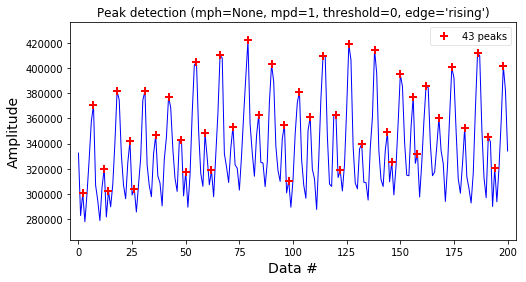

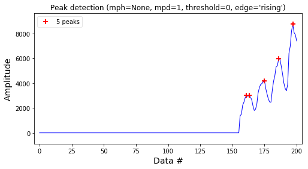

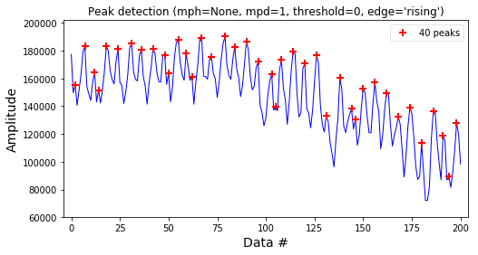

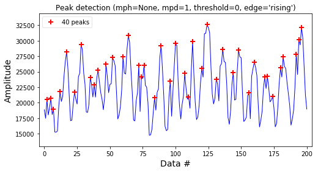

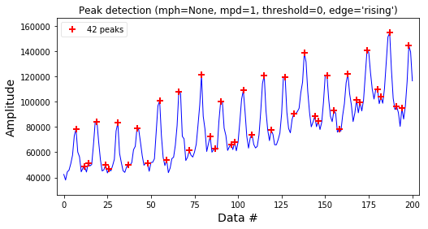

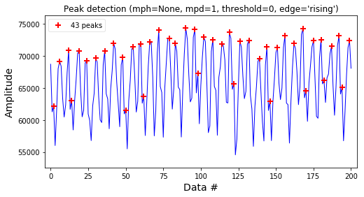

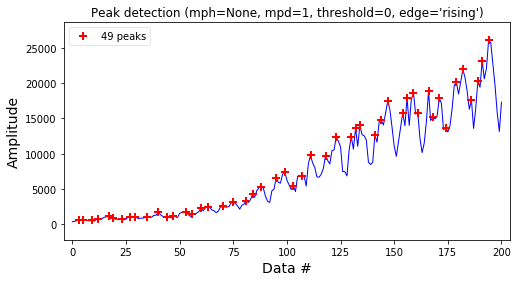

```python
peaksAllFuels = detect_peaks(data[0], show=True)
peaksSolar = detect_peaks(data[1], show=True)
peaksCoal = detect_peaks(data[2], show=True)
peaksHydro = detect_peaks(data[3], show=True)
peaksNaturalGas = detect_peaks(data[4], show=True)
peaksNuclear = detect_peaks(data[5], show=True)
peaksWind = detect_peaks(data[6], show=True)

peakData = [peaksAllFuels, peaksCoal, peaksHydro, peaksNaturalGas, peaksNuclear, peaksWind]
```

Get mean and median of all fuel maxima

```python
def meanAndMedian(x):
    meanMedianRaw = []

    for i in range(len(x)):
        interPeakDistance = 0
        medianPeakDistance = 0
        interPeakDistance = (x[i][0] + x[i][-1]) / len(x[i])
        peakDiff = np.empty(len(x[i]) - 1, dtype = int)

        for j in range(len(x[i]) - 1):
            peakDiff[j] = x[i][j + 1] - x[i][j]

        peakDiff.sort()
        lenPeakDiff = int(len(peakDiff) / 2)
        if len(peakDiff) % 2 == 0:
            medianPeakDistance = (peakDiff[lenPeakDiff] + peakDiff[lenPeakDiff - 1]) / 2
        else:
            medianPeakDistance = peakDiff[lenPeakDiff]

        meanMedianRaw.append([fuels[i], interPeakDistance, medianPeakDistance])

    meanMedianProcessed = \
        pd.DataFrame(np.asarray(meanMedianRaw), columns = ['fuel', 'mean (months)', 'median (months)'])

    return meanMedianProcessed
```

Get the dataframe

```python
meanMedian = meanAndMedian(peakData)
meanMedian
```

[output not shown]

## section 2

The previous peak analysis of our time series was based on all peaks. In the next section, the minor peaks of the allFuels dataset will be eliminated. The other datasets seem to have irregular patterns of peaking, but that's an investigation for another time

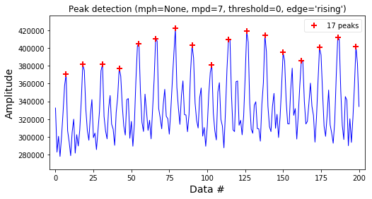

```python
peaksAllFuels = detect_peaks(data[0], mpd = 7, show=True)

peakDataMajor = [peaksAllFuels]
```

Get mean of median dataframe

```python
meanMedianMajor = meanAndMedian(peakDataMajor)
meanMedianMajor
```

|  | fuel | mean (months) | median (months) |
| --- | --- | --- | --- |
| 0 | all fuels (utility-scale) | 12.0588235294 | 12.0 |

In this case, the cycle seems to be every 12 months, peaking in the summer months